# Risk Factor Analysis

## Outcome Variable

**Outcome Variable:** ever_wasted

## Predictor Variables

**Intervention Variable:** exclfeed3

**Adjustment Set:**

- arm
- sex
- brthmon
- W_mage
- meducyrs
- feducyrs
- hhwealth_quart
- hfoodsec
- W_mhtcm
- W_mwtkg
- W_mbmi
- vagbrth
- W_gagebrth
- W_birthwt
- W_birthlen
- W_nrooms
- W_nchldlt5
- month
- W_parity
- impfloor
- impsan
- safeh20
- delta_W_mage
- delta_meducyrs
- delta_feducyrs
- delta_hhwealth_quart
- delta_hfoodsec
- delta_W_mhtcm
- delta_W_mwtkg
- delta_W_mbmi
- delta_vagbrth
- delta_W_gagebrth
- delta_W_birthwt
- delta_W_birthlen
- delta_W_nrooms
- delta_W_nchldlt5
- delta_month
- delta_W_parity
- delta_impfloor
- delta_impsan
- delta_safeh20

## Stratifying Variables

The analysis was stratified on these variable(s):

- agecat
- studyid
- country

## Data Summary

| agecat | studyid | country | exclfeed3 | ever_wasted | n_cell | n |
| --- | --- | --- | --- | --- | --- | --- |
| 0-24 months (no birth wast) | CMC-V-BCS-2002 | INDIA | 1 | 0 | 4 | 10 |
| 0-24 months (no birth wast) | CMC-V-BCS-2002 | INDIA | 1 | 1 | 6 | 10 |
| 0-24 months (no birth wast) | CMC-V-BCS-2002 | INDIA | 0 | 0 | 0 | 10 |
| 0-24 months (no birth wast) | CMC-V-BCS-2002 | INDIA | 0 | 1 | 0 | 10 |
| 0-24 months (no birth wast) | EE | PAKISTAN | 1 | 0 | 18 | 39 |
| 0-24 months (no birth wast) | EE | PAKISTAN | 1 | 1 | 21 | 39 |
| 0-24 months (no birth wast) | EE | PAKISTAN | 0 | 0 | 0 | 39 |
| 0-24 months (no birth wast) | EE | PAKISTAN | 0 | 1 | 0 | 39 |
| 0-24 months (no birth wast) | GMS-Nepal | NEPAL | 1 | 0 | 147 | 453 |
| 0-24 months (no birth wast) | GMS-Nepal | NEPAL | 1 | 1 | 229 | 453 |
| 0-24 months (no birth wast) | GMS-Nepal | NEPAL | 0 | 0 | 39 | 453 |
| 0-24 months (no birth wast) | GMS-Nepal | NEPAL | 0 | 1 | 38 | 453 |
| 0-24 months (no birth wast) | IRC | INDIA | 1 | 0 | 0 | 10 |
| 0-24 months (no birth wast) | IRC | INDIA | 1 | 1 | 0 | 10 |
| 0-24 months (no birth wast) | IRC | INDIA | 0 | 0 | 4 | 10 |
| 0-24 months (no birth wast) | IRC | INDIA | 0 | 1 | 6 | 10 |
| 0-24 months (no birth wast) | JiVitA-3 | BANGLADESH | 1 | 0 | 11034 | 14768 |
| 0-24 months (no birth wast) | JiVitA-3 | BANGLADESH | 1 | 1 | 2327 | 14768 |
| 0-24 months (no birth wast) | JiVitA-3 | BANGLADESH | 0 | 0 | 1167 | 14768 |
| 0-24 months (no birth wast) | JiVitA-3 | BANGLADESH | 0 | 1 | 240 | 14768 |
| 0-24 months (no birth wast) | JiVitA-4 | BANGLADESH | 1 | 0 | 109 | 164 |
| 0-24 months (no birth wast) | JiVitA-4 | BANGLADESH | 1 | 1 | 38 | 164 |
| 0-24 months (no birth wast) | JiVitA-4 | BANGLADESH | 0 | 0 | 13 | 164 |
| 0-24 months (no birth wast) | JiVitA-4 | BANGLADESH | 0 | 1 | 4 | 164 |
| 0-24 months (no birth wast) | Keneba | GAMBIA | 1 | 0 | 1100 | 2015 |
| 0-24 months (no birth wast) | Keneba | GAMBIA | 1 | 1 | 695 | 2015 |
| 0-24 months (no birth wast) | Keneba | GAMBIA | 0 | 0 | 120 | 2015 |
| 0-24 months (no birth wast) | Keneba | GAMBIA | 0 | 1 | 100 | 2015 |
| 0-24 months (no birth wast) | MAL-ED | BANGLADESH | 1 | 0 | 123 | 244 |
| 0-24 months (no birth wast) | MAL-ED | BANGLADESH | 1 | 1 | 36 | 244 |

[output cut: 98 more lines]

The following strata were considered:

- agecat: 0-24 months (no birth wast), studyid: CMC-V-BCS-2002, country: INDIA
- agecat: 0-24 months (no birth wast), studyid: EE, country: PAKISTAN
- agecat: 0-24 months (no birth wast), studyid: GMS-Nepal, country: NEPAL
- agecat: 0-24 months (no birth wast), studyid: IRC, country: INDIA
- agecat: 0-24 months (no birth wast), studyid: JiVitA-3, country: BANGLADESH
- agecat: 0-24 months (no birth wast), studyid: JiVitA-4, country: BANGLADESH
- agecat: 0-24 months (no birth wast), studyid: Keneba, country: GAMBIA
- agecat: 0-24 months (no birth wast), studyid: MAL-ED, country: BANGLADESH
- agecat: 0-24 months (no birth wast), studyid: MAL-ED, country: BRAZIL
- agecat: 0-24 months (no birth wast), studyid: MAL-ED, country: INDIA
- agecat: 0-24 months (no birth wast), studyid: MAL-ED, country: NEPAL
- agecat: 0-24 months (no birth wast), studyid: MAL-ED, country: PERU
- agecat: 0-24 months (no birth wast), studyid: MAL-ED, country: SOUTH AFRICA
- agecat: 0-24 months (no birth wast), studyid: MAL-ED, country: TANZANIA, UNITED REPUBLIC OF
- agecat: 0-24 months (no birth wast), studyid: PROVIDE, country: BANGLADESH
- agecat: 0-24 months (no birth wast), studyid: SAS-CompFeed, country: INDIA
- agecat: 0-6 months (no birth wast), studyid: CMC-V-BCS-2002, country: INDIA
- agecat: 0-6 months (no birth wast), studyid: EE, country: PAKISTAN
- agecat: 0-6 months (no birth wast), studyid: GMS-Nepal, country: NEPAL
- agecat: 0-6 months (no birth wast), studyid: IRC, country: INDIA
- agecat: 0-6 months (no birth wast), studyid: JiVitA-3, country: BANGLADESH
- agecat: 0-6 months (no birth wast), studyid: JiVitA-4, country: BANGLADESH
- agecat: 0-6 months (no birth wast), studyid: Keneba, country: GAMBIA
- agecat: 0-6 months (no birth wast), studyid: MAL-ED, country: BANGLADESH
- agecat: 0-6 months (no birth wast), studyid: MAL-ED, country: BRAZIL
- agecat: 0-6 months (no birth wast), studyid: MAL-ED, country: INDIA
- agecat: 0-6 months (no birth wast), studyid: MAL-ED, country: NEPAL
- agecat: 0-6 months (no birth wast), studyid: MAL-ED, country: PERU
- agecat: 0-6 months (no birth wast), studyid: MAL-ED, country: SOUTH AFRICA
- agecat: 0-6 months (no birth wast), studyid: MAL-ED, country: TANZANIA, UNITED REPUBLIC OF
- agecat: 0-6 months (no birth wast), studyid: PROVIDE, country: BANGLADESH
- agecat: 0-6 months (no birth wast), studyid: SAS-CompFeed, country: INDIA

### Dropped Strata

Some strata were dropped due to rare outcomes:

- agecat: 0-24 months (no birth wast), studyid: CMC-V-BCS-2002, country: INDIA
- agecat: 0-24 months (no birth wast), studyid: EE, country: PAKISTAN
- agecat: 0-24 months (no birth wast), studyid: IRC, country: INDIA
- agecat: 0-24 months (no birth wast), studyid: JiVitA-4, country: BANGLADESH
- agecat: 0-24 months (no birth wast), studyid: MAL-ED, country: PERU
- agecat: 0-24 months (no birth wast), studyid: MAL-ED, country: SOUTH AFRICA
- agecat: 0-6 months (no birth wast), studyid: CMC-V-BCS-2002, country: INDIA
- agecat: 0-6 months (no birth wast), studyid: EE, country: PAKISTAN
- agecat: 0-6 months (no birth wast), studyid: IRC, country: INDIA
- agecat: 0-6 months (no birth wast), studyid: JiVitA-4, country: BANGLADESH
- agecat: 0-6 months (no birth wast), studyid: MAL-ED, country: BRAZIL
- agecat: 0-6 months (no birth wast), studyid: MAL-ED, country: NEPAL
- agecat: 0-6 months (no birth wast), studyid: MAL-ED, country: PERU
- agecat: 0-6 months (no birth wast), studyid: MAL-ED, country: SOUTH AFRICA
- agecat: 0-6 months (no birth wast), studyid: MAL-ED, country: TANZANIA, UNITED REPUBLIC OF

## Methods Detail

We're interested in the causal parameters $E[Y_a]$ for all values of $a \in \mathcal{A}$. These parameters represent the mean outcome if, possibly contrary to fact, we intervened to set all units to have $A=a$. Under the randomization and positivity assumptions, these are identified by the statistical parameters $\psi_a=E_W[E_{Y|A,W}(Y|A=a,W)]$. In addition, we're interested in the mean of $Y$, $E[Y]$ under no intervention (the observed mean). We will estimate these parameters by using SuperLearner to fit the relevant likelihood factors -- $E_{Y|A,W}(Y|A=a,W)$ and $p(A=a|W)$, and then updating our likelihood fit using a joint TMLE.

For unadjusted analyses ($W=\{\}$), initial likelihoods were estimated using Lrnr_glm to estimate the simple $E(Y|A)$ and Lrnr_mean to estimate $p(A)$. For adjusted analyses, a small library containing Lrnr_glmnet, Lrnr_xgboost, and Lrnr_mean was used.

Having estimated these parameters, we will then use the delta method to estimate relative risks and attributable risks relative to a prespecified baseline level of $A$.

# Results Detail

## Results Plots

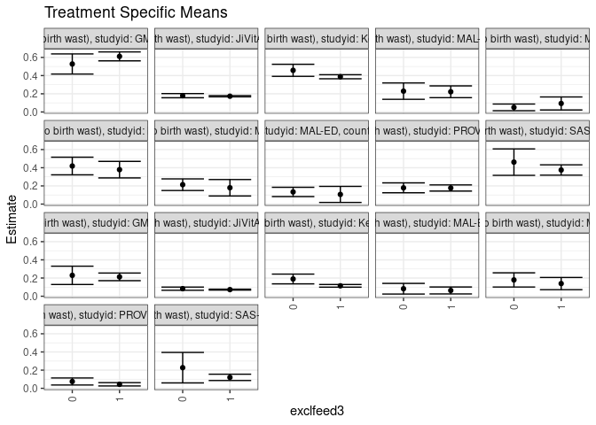

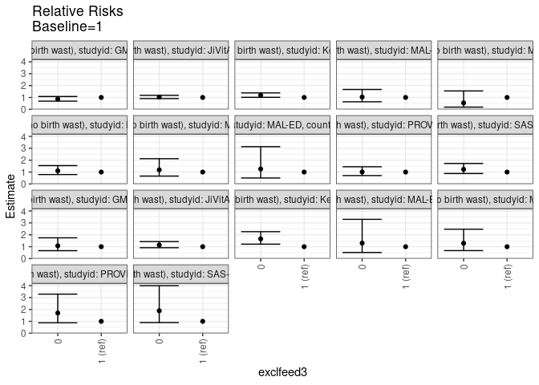

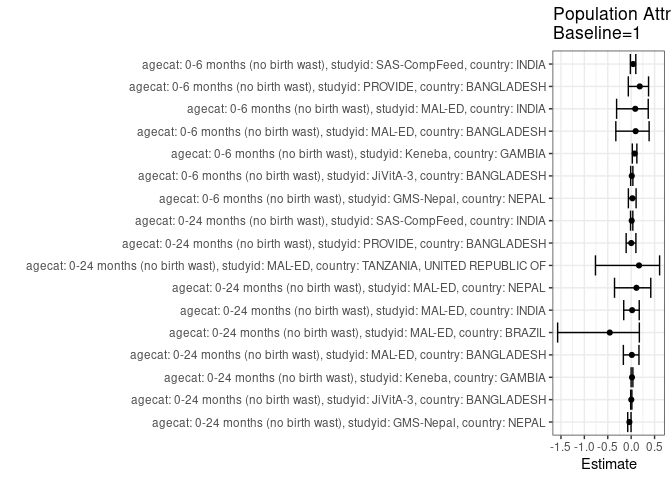

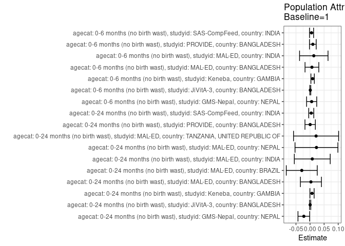

## Results Table

### Parameter: TSM

| agecat | studyid | country | intervention_level | baseline_level | estimate | ci_lower | ci_upper |
| --- | --- | --- | --- | --- | --- | --- | --- |
| 0-24 months (no birth wast) | GMS-Nepal | NEPAL | 1 | NA | 0.6114688 | 0.5622911 | 0.6606465 |
| 0-24 months (no birth wast) | GMS-Nepal | NEPAL | 0 | NA | 0.5277940 | 0.4171190 | 0.6384691 |
| 0-24 months (no birth wast) | JiVitA-3 | BANGLADESH | 1 | NA | 0.1733786 | 0.1664162 | 0.1803409 |
| 0-24 months (no birth wast) | JiVitA-3 | BANGLADESH | 0 | NA | 0.1792857 | 0.1564733 | 0.2020980 |
| 0-24 months (no birth wast) | Keneba | GAMBIA | 1 | NA | 0.3875430 | 0.3650493 | 0.4100366 |
| 0-24 months (no birth wast) | Keneba | GAMBIA | 0 | NA | 0.4580715 | 0.3915529 | 0.5245902 |
| 0-24 months (no birth wast) | MAL-ED | BANGLADESH | 1 | NA | 0.2222777 | 0.1575337 | 0.2870217 |
| 0-24 months (no birth wast) | MAL-ED | BANGLADESH | 0 | NA | 0.2291754 | 0.1392036 | 0.3191471 |
| 0-24 months (no birth wast) | MAL-ED | BRAZIL | 1 | NA | 0.0937500 | 0.0221611 | 0.1653389 |
| 0-24 months (no birth wast) | MAL-ED | BRAZIL | 0 | NA | 0.0507246 | 0.0140225 | 0.0874268 |
| 0-24 months (no birth wast) | MAL-ED | INDIA | 1 | NA | 0.3788865 | 0.2880574 | 0.4697156 |
| 0-24 months (no birth wast) | MAL-ED | INDIA | 0 | NA | 0.4187529 | 0.3216528 | 0.5158531 |
| 0-24 months (no birth wast) | MAL-ED | NEPAL | 1 | NA | 0.1798704 | 0.0894244 | 0.2703164 |
| 0-24 months (no birth wast) | MAL-ED | NEPAL | 0 | NA | 0.2134725 | 0.1495001 | 0.2774450 |
| 0-24 months (no birth wast) | MAL-ED | TANZANIA, UNITED REPUBLIC OF | 1 | NA | 0.1063830 | 0.0180333 | 0.1947326 |
| 0-24 months (no birth wast) | MAL-ED | TANZANIA, UNITED REPUBLIC OF | 0 | NA | 0.1337209 | 0.0827402 | 0.1847017 |
| 0-24 months (no birth wast) | PROVIDE | BANGLADESH | 1 | NA | 0.1771554 | 0.1432368 | 0.2110739 |
| 0-24 months (no birth wast) | PROVIDE | BANGLADESH | 0 | NA | 0.1788823 | 0.1244104 | 0.2333542 |
| 0-24 months (no birth wast) | SAS-CompFeed | INDIA | 1 | NA | 0.3749192 | 0.3179202 | 0.4319182 |
| 0-24 months (no birth wast) | SAS-CompFeed | INDIA | 0 | NA | 0.4616077 | 0.3160035 | 0.6072120 |
| 0-6 months (no birth wast) | GMS-Nepal | NEPAL | 1 | NA | 0.2129402 | 0.1708954 | 0.2549849 |
| 0-6 months (no birth wast) | GMS-Nepal | NEPAL | 0 | NA | 0.2294764 | 0.1288166 | 0.3301362 |
| 0-6 months (no birth wast) | JiVitA-3 | BANGLADESH | 1 | NA | 0.0725847 | 0.0674591 | 0.0777103 |
| 0-6 months (no birth wast) | JiVitA-3 | BANGLADESH | 0 | NA | 0.0829858 | 0.0653255 | 0.1006462 |
| 0-6 months (no birth wast) | Keneba | GAMBIA | 1 | NA | 0.1142701 | 0.0995058 | 0.1290344 |
| 0-6 months (no birth wast) | Keneba | GAMBIA | 0 | NA | 0.1894456 | 0.1357810 | 0.2431102 |
| 0-6 months (no birth wast) | MAL-ED | BANGLADESH | 1 | NA | 0.0632911 | 0.0252469 | 0.1013354 |
| 0-6 months (no birth wast) | MAL-ED | BANGLADESH | 0 | NA | 0.0823529 | 0.0237915 | 0.1409143 |
| 0-6 months (no birth wast) | MAL-ED | INDIA | 1 | NA | 0.1390672 | 0.0719849 | 0.2061495 |
| 0-6 months (no birth wast) | MAL-ED | INDIA | 0 | NA | 0.1791294 | 0.1011525 | 0.2571063 |
| 0-6 months (no birth wast) | PROVIDE | BANGLADESH | 1 | NA | 0.0442484 | 0.0259828 | 0.0625140 |
| 0-6 months (no birth wast) | PROVIDE | BANGLADESH | 0 | NA | 0.0751398 | 0.0364930 | 0.1137866 |
| 0-6 months (no birth wast) | SAS-CompFeed | INDIA | 1 | NA | 0.1204819 | 0.0857775 | 0.1551864 |
| 0-6 months (no birth wast) | SAS-CompFeed | INDIA | 0 | NA | 0.2272727 | 0.0595457 | 0.3949997 |

### Parameter: E(Y)

| agecat | studyid | country | intervention_level | baseline_level | estimate | ci_lower | ci_upper |
| --- | --- | --- | --- | --- | --- | --- | --- |
| 0-24 months (no birth wast) | GMS-Nepal | NEPAL | NA | NA | 0.5894040 | 0.5440524 | 0.6347556 |
| 0-24 months (no birth wast) | JiVitA-3 | BANGLADESH | NA | NA | 0.1738218 | 0.1671074 | 0.1805361 |
| 0-24 months (no birth wast) | Keneba | GAMBIA | NA | NA | 0.3945409 | 0.3731954 | 0.4158865 |
| 0-24 months (no birth wast) | MAL-ED | BANGLADESH | NA | NA | 0.2254098 | 0.1728726 | 0.2779471 |
| 0-24 months (no birth wast) | MAL-ED | BRAZIL | NA | NA | 0.0643564 | 0.0304329 | 0.0982800 |
| 0-24 months (no birth wast) | MAL-ED | INDIA | NA | NA | 0.3867925 | 0.3210797 | 0.4525052 |
| 0-24 months (no birth wast) | MAL-ED | NEPAL | NA | NA | 0.2026432 | 0.1502365 | 0.2550498 |
| 0-24 months (no birth wast) | MAL-ED | TANZANIA, UNITED REPUBLIC OF | NA | NA | 0.1278539 | 0.0835266 | 0.1721812 |
| 0-24 months (no birth wast) | PROVIDE | BANGLADESH | NA | NA | 0.1775837 | 0.1489858 | 0.2061816 |
| 0-24 months (no birth wast) | SAS-CompFeed | INDIA | NA | NA | 0.3792325 | 0.3255512 | 0.4329138 |
| 0-6 months (no birth wast) | GMS-Nepal | NEPAL | NA | NA | 0.2186788 | 0.1799683 | 0.2573894 |
| 0-6 months (no birth wast) | JiVitA-3 | BANGLADESH | NA | NA | 0.0735505 | 0.0685774 | 0.0785236 |
| 0-6 months (no birth wast) | Keneba | GAMBIA | NA | NA | 0.1234383 | 0.1090221 | 0.1378544 |
| 0-6 months (no birth wast) | MAL-ED | BANGLADESH | NA | NA | 0.0699588 | 0.0378213 | 0.1020964 |
| 0-6 months (no birth wast) | MAL-ED | INDIA | NA | NA | 0.1523810 | 0.1036572 | 0.2011047 |
| 0-6 months (no birth wast) | PROVIDE | BANGLADESH | NA | NA | 0.0541728 | 0.0371844 | 0.0711612 |
| 0-6 months (no birth wast) | SAS-CompFeed | INDIA | NA | NA | 0.1258581 | 0.0910745 | 0.1606418 |

### Parameter: RR

| agecat | studyid | country | intervention_level | baseline_level | estimate | ci_lower | ci_upper |
| --- | --- | --- | --- | --- | --- | --- | --- |
| 0-24 months (no birth wast) | GMS-Nepal | NEPAL | 1 | 1 | 1.0000000 | 1.0000000 | 1.000000 |
| 0-24 months (no birth wast) | GMS-Nepal | NEPAL | 0 | 1 | 0.8631577 | 0.6906992 | 1.078677 |
| 0-24 months (no birth wast) | JiVitA-3 | BANGLADESH | 1 | 1 | 1.0000000 | 1.0000000 | 1.000000 |
| 0-24 months (no birth wast) | JiVitA-3 | BANGLADESH | 0 | 1 | 1.0340705 | 0.9056947 | 1.180643 |
| 0-24 months (no birth wast) | Keneba | GAMBIA | 1 | 1 | 1.0000000 | 1.0000000 | 1.000000 |
| 0-24 months (no birth wast) | Keneba | GAMBIA | 0 | 1 | 1.1819890 | 1.0114071 | 1.381341 |
| 0-24 months (no birth wast) | MAL-ED | BANGLADESH | 1 | 1 | 1.0000000 | 1.0000000 | 1.000000 |
| 0-24 months (no birth wast) | MAL-ED | BANGLADESH | 0 | 1 | 1.0310319 | 0.6355269 | 1.672670 |
| 0-24 months (no birth wast) | MAL-ED | BRAZIL | 1 | 1 | 1.0000000 | 1.0000000 | 1.000000 |
| 0-24 months (no birth wast) | MAL-ED | BRAZIL | 0 | 1 | 0.5410628 | 0.1889656 | 1.549219 |
| 0-24 months (no birth wast) | MAL-ED | INDIA | 1 | 1 | 1.0000000 | 1.0000000 | 1.000000 |
| 0-24 months (no birth wast) | MAL-ED | INDIA | 0 | 1 | 1.1052200 | 0.7911129 | 1.544042 |
| 0-24 months (no birth wast) | MAL-ED | NEPAL | 1 | 1 | 1.0000000 | 1.0000000 | 1.000000 |
| 0-24 months (no birth wast) | MAL-ED | NEPAL | 0 | 1 | 1.1868131 | 0.6628250 | 2.125033 |
| 0-24 months (no birth wast) | MAL-ED | TANZANIA, UNITED REPUBLIC OF | 1 | 1 | 1.0000000 | 1.0000000 | 1.000000 |
| 0-24 months (no birth wast) | MAL-ED | TANZANIA, UNITED REPUBLIC OF | 0 | 1 | 1.2569767 | 0.5040371 | 3.134671 |
| 0-24 months (no birth wast) | PROVIDE | BANGLADESH | 1 | 1 | 1.0000000 | 1.0000000 | 1.000000 |
| 0-24 months (no birth wast) | PROVIDE | BANGLADESH | 0 | 1 | 1.0097481 | 0.7045426 | 1.447168 |
| 0-24 months (no birth wast) | SAS-CompFeed | INDIA | 1 | 1 | 1.0000000 | 1.0000000 | 1.000000 |
| 0-24 months (no birth wast) | SAS-CompFeed | INDIA | 0 | 1 | 1.2312191 | 0.8795362 | 1.723523 |
| 0-6 months (no birth wast) | GMS-Nepal | NEPAL | 1 | 1 | 1.0000000 | 1.0000000 | 1.000000 |
| 0-6 months (no birth wast) | GMS-Nepal | NEPAL | 0 | 1 | 1.0776568 | 0.6652980 | 1.745600 |
| 0-6 months (no birth wast) | JiVitA-3 | BANGLADESH | 1 | 1 | 1.0000000 | 1.0000000 | 1.000000 |
| 0-6 months (no birth wast) | JiVitA-3 | BANGLADESH | 0 | 1 | 1.1432961 | 0.9153752 | 1.427967 |
| 0-6 months (no birth wast) | Keneba | GAMBIA | 1 | 1 | 1.0000000 | 1.0000000 | 1.000000 |
| 0-6 months (no birth wast) | Keneba | GAMBIA | 0 | 1 | 1.6578749 | 1.2144122 | 2.263275 |
| 0-6 months (no birth wast) | MAL-ED | BANGLADESH | 1 | 1 | 1.0000000 | 1.0000000 | 1.000000 |
| 0-6 months (no birth wast) | MAL-ED | BANGLADESH | 0 | 1 | 1.3011765 | 0.5128087 | 3.301544 |
| 0-6 months (no birth wast) | MAL-ED | INDIA | 1 | 1 | 1.0000000 | 1.0000000 | 1.000000 |
| 0-6 months (no birth wast) | MAL-ED | INDIA | 0 | 1 | 1.2880778 | 0.6717729 | 2.469800 |
| 0-6 months (no birth wast) | PROVIDE | BANGLADESH | 1 | 1 | 1.0000000 | 1.0000000 | 1.000000 |
| 0-6 months (no birth wast) | PROVIDE | BANGLADESH | 0 | 1 | 1.6981362 | 0.8778379 | 3.284965 |
| 0-6 months (no birth wast) | SAS-CompFeed | INDIA | 1 | 1 | 1.0000000 | 1.0000000 | 1.000000 |
| 0-6 months (no birth wast) | SAS-CompFeed | INDIA | 0 | 1 | 1.8863636 | 0.8915751 | 3.991103 |

### Parameter: PAR

| agecat | studyid | country | intervention_level | baseline_level | estimate | ci_lower | ci_upper |
| --- | --- | --- | --- | --- | --- | --- | --- |
| 0-24 months (no birth wast) | GMS-Nepal | NEPAL | 1 | NA | -0.0220648 | -0.0428632 | -0.0012665 |
| 0-24 months (no birth wast) | JiVitA-3 | BANGLADESH | 1 | NA | 0.0004432 | -0.0017922 | 0.0026786 |
| 0-24 months (no birth wast) | Keneba | GAMBIA | 1 | NA | 0.0069980 | -0.0005068 | 0.0145027 |
| 0-24 months (no birth wast) | MAL-ED | BANGLADESH | 1 | NA | 0.0031321 | -0.0342553 | 0.0405196 |
| 0-24 months (no birth wast) | MAL-ED | BRAZIL | 1 | NA | -0.0293936 | -0.0844233 | 0.0256361 |
| 0-24 months (no birth wast) | MAL-ED | INDIA | 1 | NA | 0.0079060 | -0.0558685 | 0.0716804 |
| 0-24 months (no birth wast) | MAL-ED | NEPAL | 1 | NA | 0.0227728 | -0.0534535 | 0.0989990 |
| 0-24 months (no birth wast) | MAL-ED | TANZANIA, UNITED REPUBLIC OF | 1 | NA | 0.0214709 | -0.0586552 | 0.1015970 |
| 0-24 months (no birth wast) | PROVIDE | BANGLADESH | 1 | NA | 0.0004283 | -0.0180398 | 0.0188965 |
| 0-24 months (no birth wast) | SAS-CompFeed | INDIA | 1 | NA | 0.0043133 | -0.0046855 | 0.0133121 |
| 0-6 months (no birth wast) | GMS-Nepal | NEPAL | 1 | NA | 0.0057387 | -0.0122510 | 0.0237283 |
| 0-6 months (no birth wast) | JiVitA-3 | BANGLADESH | 1 | NA | 0.0009658 | -0.0007704 | 0.0027020 |
| 0-6 months (no birth wast) | Keneba | GAMBIA | 1 | NA | 0.0091681 | 0.0031235 | 0.0152128 |
| 0-6 months (no birth wast) | MAL-ED | BANGLADESH | 1 | NA | 0.0066677 | -0.0177867 | 0.0311221 |
| 0-6 months (no birth wast) | MAL-ED | INDIA | 1 | NA | 0.0133137 | -0.0372637 | 0.0638912 |
| 0-6 months (no birth wast) | PROVIDE | BANGLADESH | 1 | NA | 0.0099244 | -0.0019927 | 0.0218414 |
| 0-6 months (no birth wast) | SAS-CompFeed | INDIA | 1 | NA | 0.0053762 | -0.0018898 | 0.0126422 |

### Parameter: PAF

| agecat | studyid | country | intervention_level | baseline_level | estimate | ci_lower | ci_upper |
| --- | --- | --- | --- | --- | --- | --- | --- |
| 0-24 months (no birth wast) | GMS-Nepal | NEPAL | 1 | NA | -0.0374358 | -0.0735628 | -0.0025246 |
| 0-24 months (no birth wast) | JiVitA-3 | BANGLADESH | 1 | NA | 0.0025497 | -0.0103889 | 0.0153227 |
| 0-24 months (no birth wast) | Keneba | GAMBIA | 1 | NA | 0.0177370 | -0.0014763 | 0.0365817 |
| 0-24 months (no birth wast) | MAL-ED | BANGLADESH | 1 | NA | 0.0138953 | -0.1668050 | 0.1666111 |
| 0-24 months (no birth wast) | MAL-ED | BRAZIL | 1 | NA | -0.4567308 | -1.5709361 | 0.1745946 |
| 0-24 months (no birth wast) | MAL-ED | INDIA | 1 | NA | 0.0204398 | -0.1591062 | 0.1721741 |
| 0-24 months (no birth wast) | MAL-ED | NEPAL | 1 | NA | 0.1123787 | -0.3556707 | 0.4188326 |
| 0-24 months (no birth wast) | MAL-ED | TANZANIA, UNITED REPUBLIC OF | 1 | NA | 0.1679331 | -0.7627614 | 0.6072439 |
| 0-24 months (no birth wast) | PROVIDE | BANGLADESH | 1 | NA | 0.0024121 | -0.1071964 | 0.1011697 |
| 0-24 months (no birth wast) | SAS-CompFeed | INDIA | 1 | NA | 0.0113737 | -0.0131809 | 0.0353333 |
| 0-6 months (no birth wast) | GMS-Nepal | NEPAL | 1 | NA | 0.0262424 | -0.0595430 | 0.1050822 |
| 0-6 months (no birth wast) | JiVitA-3 | BANGLADESH | 1 | NA | 0.0131311 | -0.0106978 | 0.0363982 |
| 0-6 months (no birth wast) | Keneba | GAMBIA | 1 | NA | 0.0742731 | 0.0245628 | 0.1214501 |
| 0-6 months (no birth wast) | MAL-ED | BANGLADESH | 1 | NA | 0.0953090 | -0.3278890 | 0.3836339 |
| 0-6 months (no birth wast) | MAL-ED | INDIA | 1 | NA | 0.0873714 | -0.3111002 | 0.3647389 |
| 0-6 months (no birth wast) | PROVIDE | BANGLADESH | 1 | NA | 0.1831982 | -0.0609731 | 0.3711762 |
| 0-6 months (no birth wast) | SAS-CompFeed | INDIA | 1 | NA | 0.0427163 | -0.0166271 | 0.0985957 |